# Final Project

Team 7

4/5/2025

# Team 7 - Pair Trading

Pairs trading is a market-neutral strategy that involves identifying two historically correlated assets and profiting from temporary divergences in their price relationship. The idea is to go long on the undervalued asset and short on the overvalued one, betting that their prices will revert to their historical mean. This strategy relies on statistical techniques like cointegration and spread analysis to detect and exploit these opportunities, making it popular in quantitative and algorithmic trading.

## Pair Selection

Pair selection is a critical step in pairs trading, and cointegration testing is a widely used method for identifying suitable pairs. Cointegration measures whether a stable, long-term relationship exists between two non-stationary price series, indicating that their price spread is mean-reverting over time. This property is essential for the success of a pairs trading strategy.

Initially, we used the *Johansen co-integration test* on our initial stock selection,Visa (V) & Mastercard (MA) and Coca-Cola (KO) & Pepsi (PEP).

Based on the work of [Prof. Daniel P. Palomar](https://palomar.home.ece.ust.hk/MAFS5310_lectures/Rsession_pairs_trading_with_R.html) We switch to use the Engle-Granger co-integration test and other unit-root tests. The test, given two series $x(t)$ and $y(t)$, finds parameters $\alpha, \beta, \rho$ such that:

$$y(t) = \alpha + \beta x(t) + r(t) \\
r(t) = \rho(t-1) + \epsilon(t)$$

where $r(t)$ is the residual and $\epsilon(t)$ is the error term. If $|\rho|<1$ , then $x(t)$ and $y(t)$ are co-integrated.

We also use the Augmented Dickey-Fuller (ADF) test, to measure the how much smaller than 1 the value of $|\rho|$ is.

## Coca Cola and Pepsi

First, we assess the co-integration on KO and PEP.

```r
library(quantmod)
```

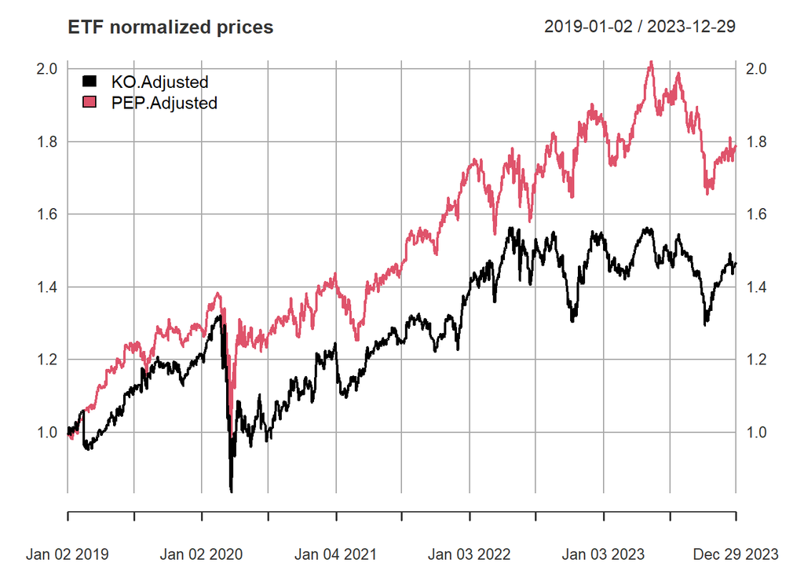

```r
library(egcm)  #install.packages("egcm")
egcm.set.default.pvalue(0.01)

#Retrieve KO and PEP Prices
KO_prices = Ad(getSymbols("KO", from = "2019-01-01", to = "2023-12-31", auto.assign = FALSE))
PEP_prices = Ad(getSymbols("PEP", from = "2019-01-01", to = "2023-12-31", auto.assign = FALSE))


# check cointegration of prices
plot(cbind(KO_prices/as.numeric(KO_prices[1]), PEP_prices/as.numeric(PEP_prices[1])),
     legend.loc = "topleft", main = "ETF normalized prices")
```

```r
print(egcm(KO_prices, PEP_prices))
```

```
## PEP.Adjusted[i] =   3.2981 KO.Adjusted[i] -  25.9260 + R[i], R[i] =   0.9903 R[i-1] + eps[i], eps ~ N(0,  1.3083^2)
##                    (0.0321)                  (1.7189)                (0.0048)
##
## R[2023-12-29] = 1.3894 (t = 0.179)
##
## WARNING: KO.Adjusted and PEP.Adjusted do not appear to be cointegrated.
```

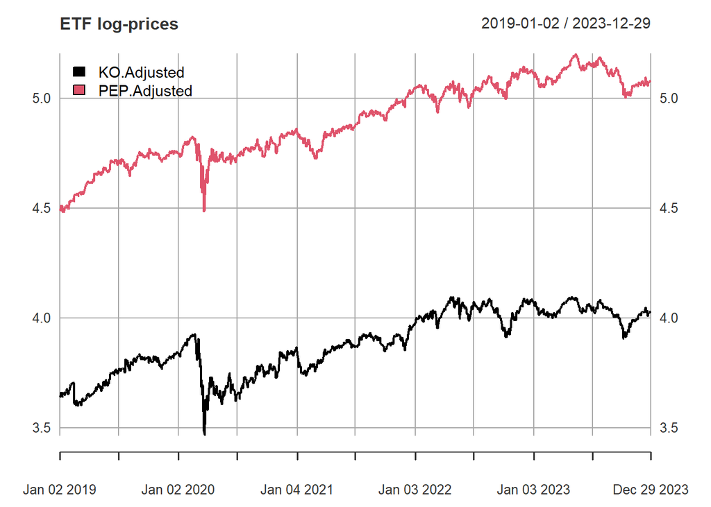

```r
plot(log(cbind(KO_prices, PEP_prices)), legend.loc = "topleft", main = "ETF log-prices")
```

```r
res = egcm(KO_prices, PEP_prices, log = TRUE)
print(res)
```

```
## PEP.Adjusted[i] =   1.1847 KO.Adjusted[i] +   0.2956 + R[i], R[i] =   0.9882 R[i-1] + eps[i], eps ~ N(0,  0.0105^2)
##                    (0.0118)                  (0.0463)                (0.0050)
##
## R[2023-12-29] = 0.0114 (t = 0.191)
##
## WARNING: KO.Adjusted and PEP.Adjusted do not appear to be cointegrated.
```

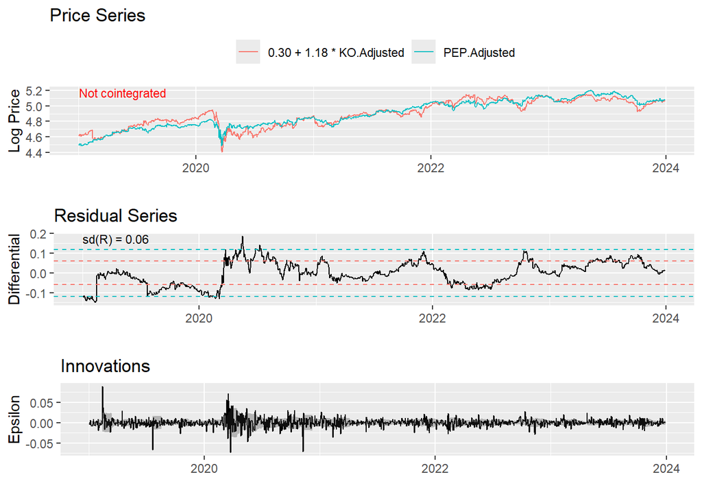

```r
plot(res)
```

From the result, we observe that the series is not always co-integrated.

We now expand to test different assets.

## New Pair Selection

One option we can test is GLD (SPDR Gold shares) and IAU (iShares Gold Trust). Both are ETFs that track the price of gold and are very highly correlated.

We alter our time frame:

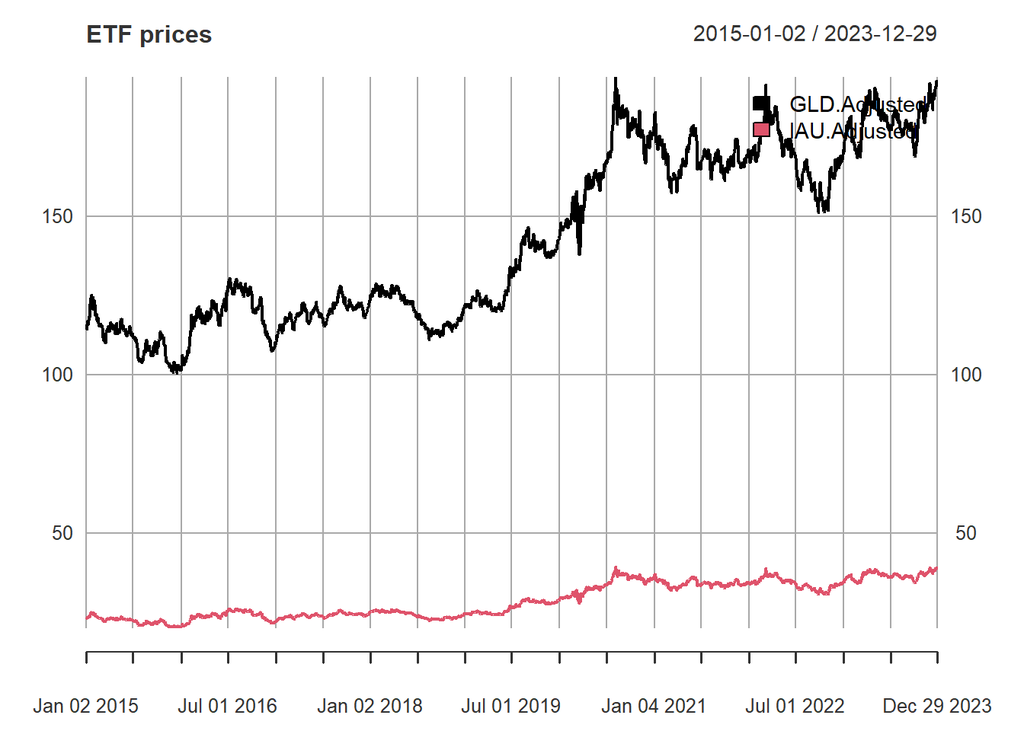

```r
GLD_prices = Ad(getSymbols("GLD", from = "2015-01-01", to = "2023-12-31", auto.assign = FALSE))
IAU_prices = Ad(getSymbols("IAU", from = "2015-01-01", to = "2023-12-31", auto.assign = FALSE))
plot(cbind(GLD_prices, IAU_prices), legend.loc = "topright", main = "ETF prices")
```

```r
cor(GLD_prices,IAU_prices)
```

```
##              IAU.Adjusted
## GLD.Adjusted    0.9999633
```

## Methodology

### Co-integration and Stationarity

To measure their co-integration, we take the log price of both ETFs and if they are co-integrated, then the spread between both should be stationary.

Co-integration means there’s a long-run equilibrium relationship between the two price series. Therefore, even though each log-price drifts, their spread tends to revert to a mean over time. This happens because any deviation from the long-run relationship creates pressure that pulls the other series back towards equilibrium. This explains why the spread should be stationary.

### Least Square regression

Let $y_{t1}$ denote the log price of the first ETF and similarly, $y_{2t}$. As mentioned the spread $z_t = y_{1t} - y_{2t}$ is stationary and can be written as

$$z_t = y_{1t} - \gamma y_{2t} = \mu +\epsilon_t$$

$\mu$ represents the long term mean and $\epsilon_t$ is the zero- mean residual. We can rewrite this as

$$y_{1t} = \mu +\gamma y_{2t} + \epsilon_t$$
which now represents a least square regression.

This can be re-written as

$$\epsilon_t = y_{1t} -( \mu +\gamma y_{2t})$$

Our goal now is to re-reduce the error term over time range of the data

```r
library(xts)
library(quantmod)
# combining both prices into one table
prices = cbind(GLD_prices, IAU_prices)
# Number of data points
N = nrow(prices)
#checking for any NAs
anyNA(prices)
```

```
## [1] FALSE
```

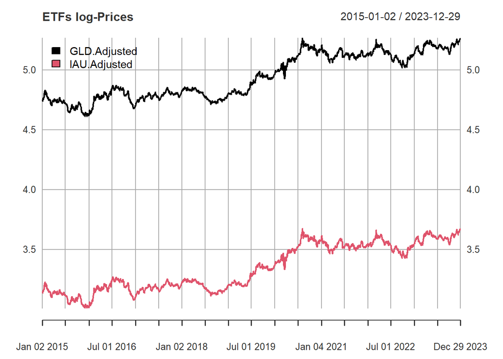

```r
# taking the log

logprices = log(prices)
plot(logprices, legend.loc = "topleft", main = "ETFs log-Prices")
```

After plotting the log-prices of the ETF, we will now try to estimate $\gamma$ and $\mu$.

Given the long history of prices we are given, we will divide the data into training and testing data.

```r
# defining the training set

prices_train = round(0.8*N)
prices_test = N - prices_train
y1 = logprices[,1]
y2 = logprices[,2]


reg = lm(y1[1:prices_train] ~ y2[1:prices_train])
reg$coefficients
```

```
##        (Intercept) y2[1:prices_train]
##          1.6496120          0.9839086
```

```r
mu = reg$coefficients[1]
gamma = reg$coefficients[2]
```

Now, for visualization, we plot the log price of one ETF based on its regression.

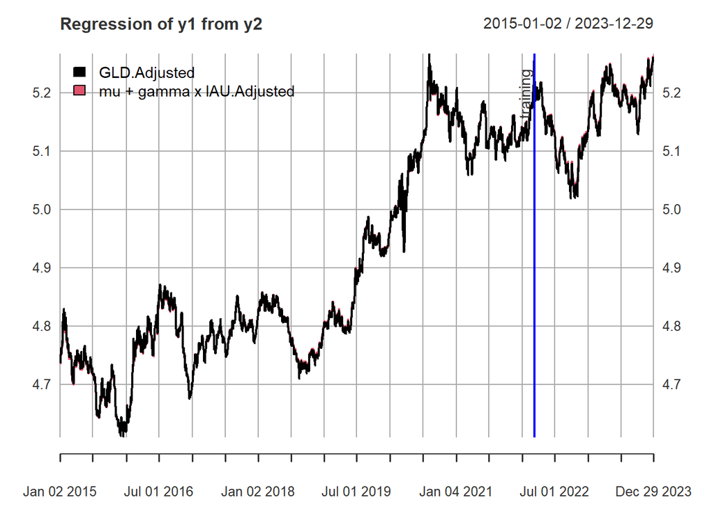

```r
tmp = cbind(y1, mu + gamma*y2)
colnames(tmp) = c(colnames(y1), paste("mu + gamma x", colnames(y2)))
{ plot(tmp, legend.loc = "topleft", main = "Regression of y1 from y2")
  addEventLines(xts("training", index(y1[prices_train])), srt = 90, pos = 2, lwd = 2, col = "blue") }
```

and the spread.

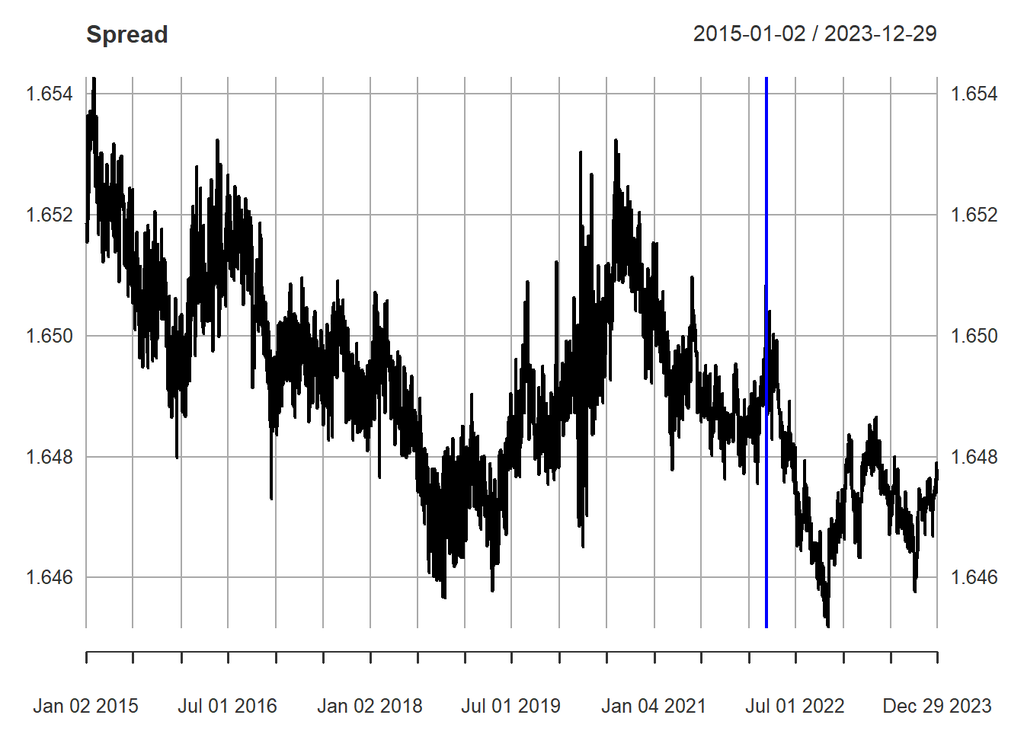

```r
spread = y1 - gamma*y2
{ plot(spread, main = "Spread")
  addEventLines(xts("", index(y1[prices_train])), lwd = 2, col = "blue") }
```

Now, we run a co-integration test.

```r
coint_result = egcm(y1, y2, p.value = 0.05)
print(coint_result)
```

```
## IAU.Adjusted[i] =   1.0189 GLD.Adjusted[i] -   1.6887 + R[i], R[i] =   0.9026 R[i-1] + eps[i], eps ~ N(0,  0.0007^2)
##                    (0.0002)                   (0.0010)                (0.0092)
##
## R[2023-12-29] = 0.0006 (t = 0.367)
##
## WARNING: The series seem cointegrated but the residuals are not AR(1).
```

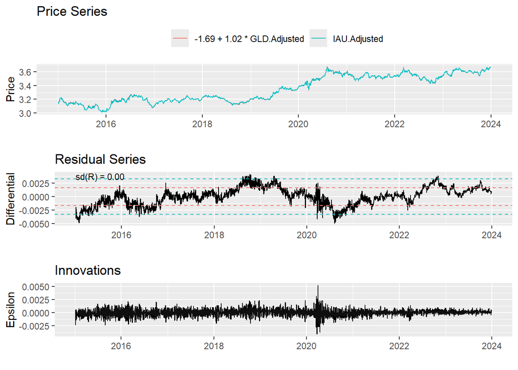

```r
plot(coint_result)
```

### Trading the spread

The spread $z_t = y_{1t} - y_{2t}$ translates to the equivalent of shorting one ETF and longing the other. $z_t$ can also be represented with a weight vector with entries $1$ and $-\gamma$

We normalize it and the resulting weight vector now has entries $1/(1+\gamma)$ and $-\gamma/(1+\gamma)$

```r
w = c(1, -gamma)/(1+gamma)

sum(abs(w)) # ensuring it sums up to one
```

```
## [1] 1
```

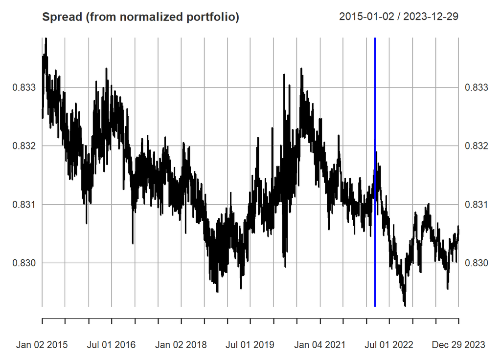

```r
w_spread = matrix(w , N ,2, byrow = TRUE)
w_spread =xts(w_spread,index(y1))
colnames(w_spread) = c("w1","w2")

spread = rowSums(cbind(y1,y2)* w_spread)
spread = xts(spread, index(y1))
colnames(spread) = "spread"
{ plot(spread, main = "Spread (from normalized portfolio)")
  addEventLines(xts("", index(y1[prices_train])), lwd = 2, col = "blue") }
```

The Z-score is the normalized version of spread, which can be used to generate the trading signal.

$$Z =\frac{z_t - E[z_t]}{Std Dev[z_t]}$$

To generate the Z-score

```r
spread_mean = mean(spread[1:prices_train], na.rm = TRUE)
spread_var = as.numeric(var(spread[1:prices_train], na.rm = TRUE))
Z_score = (spread-spread_mean)/sqrt(spread_var)
colnames(Z_score) = "Z-score"
threshold_long = threshold_short = Z_score
threshold_short[] = .7
threshold_long[] = -.7
```

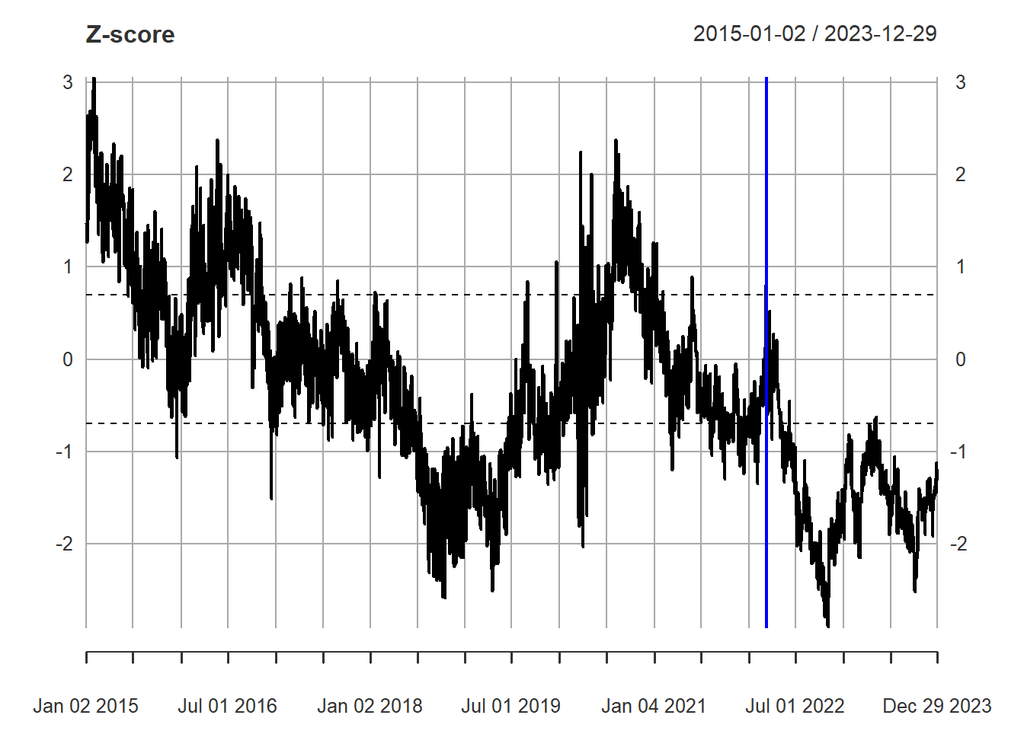

```r
{ plot(Z_score, main = "Z-score")
  lines(threshold_short, lty = 2)
  lines(threshold_long, lty = 2)
  addEventLines(xts("", index(y1[prices_train])), lwd = 2, col = "blue") }
```

Now, we generate the trading signal

$$0 : no \ position \\
1 : long \ position \\
-1 : short \ position$$

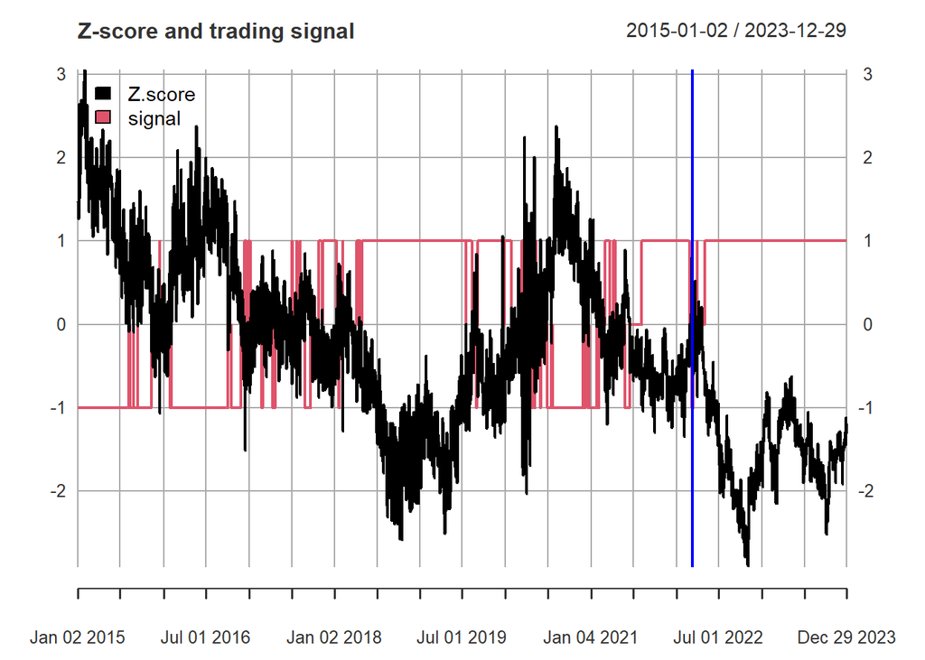

```r
#based on https://palomar.home.ece.ust.hk/MAFS5310_lectures/Rsession_pairs_trading_with_R.html

generate_signal <- function(Z_score, threshold_long, threshold_short) {
  signal <- Z_score
  colnames(signal) <- "signal"
  signal[] <- NA

  #initial position
  signal[1] <- 0
  if (Z_score[1] <= threshold_long[1]) {
    signal[1] <- 1
  } else if (Z_score[1] >= threshold_short[1])
    signal[1] <- -1

  # loop
  for (t in 2:nrow(Z_score)) {
    if (signal[t-1] == 0) {  #if we were in no position
      if (Z_score[t] <= threshold_long[t]) {
        signal[t] <- 1
      } else if(Z_score[t] >= threshold_short[t]) {
        signal[t] <- -1
      } else signal[t] <- 0
    } else if (signal[t-1] == 1) {  #if we were in a long position
      if (Z_score[t] >= 0) signal[t] <- 0
      else signal[t] <- signal[t-1]
    } else {  #if we were in a short position
      if (Z_score[t] <= 0) signal[t] <- 0
      else signal[t] <- signal[t-1]
    }
  }
  return(signal)
}

# now just invoke the function
signal <- generate_signal(Z_score, threshold_long, threshold_short)


{ plot(cbind(Z_score, signal), main = "Z-score and trading signal", legend.loc = "topleft")
  addEventLines(xts("", index(y1[prices_train])), lwd = 2, col = "blue") }
```

## Calculating Returns

Finally, we compute the return and Profit/Loss on this strategy.

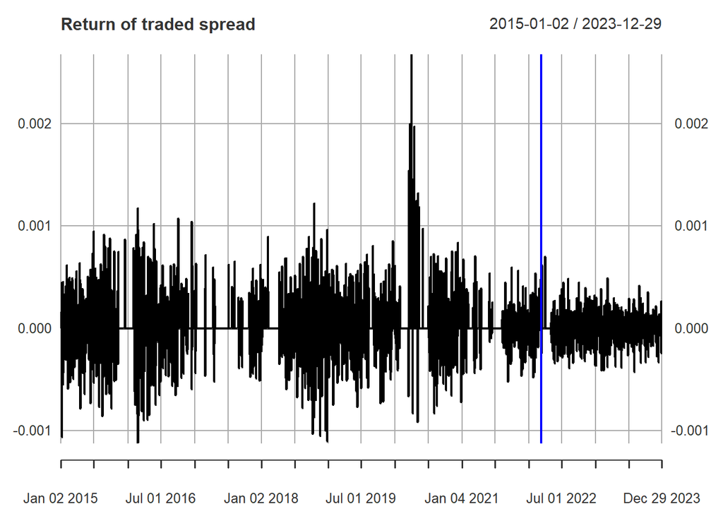

```r
spread_return <- diff(spread)
traded_return <- spread_return * lag(signal)
traded_return[is.na(traded_return)] <- 0
colnames(traded_return) <- "traded spread"
{ plot(traded_return, main = "Return of traded spread")
  addEventLines(xts("", index(y1[prices_train])), lwd = 2, col = "blue") }
```

Calculating the Profit/Loss using re-investment

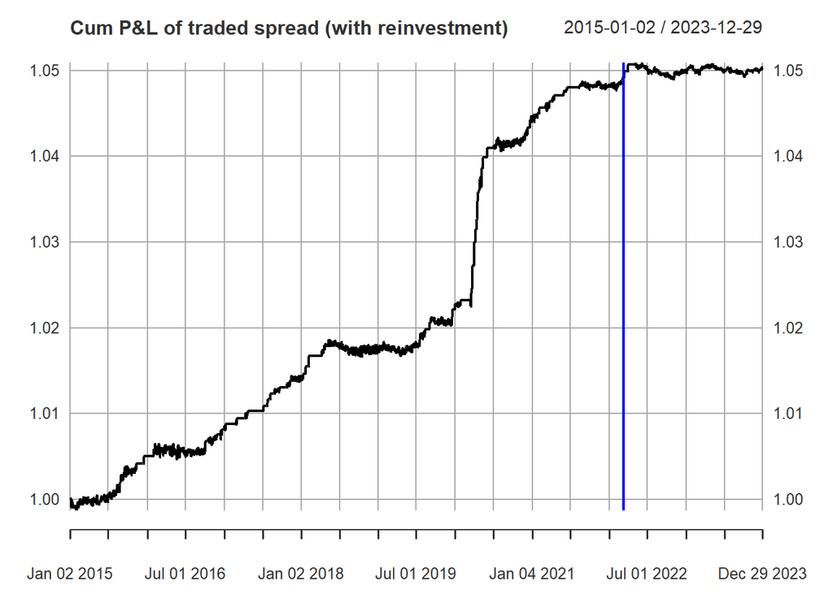

```r
{ plot(cumprod(1 + traded_return), main = "Cum P&L of traded spread (with reinvestment)")
  addEventLines(xts("", index(y1[prices_train])), lwd = 2, col = "blue") }
```

## Discussion and Conclusion

Notice that $\gamma$ and $\mu$ are constantly changing and need to be re-calculated over time, this is noticeable, as the spread bounds in the later years changes.